# Lab 5 - Spatio-temoral estimation and prediction of ozone concentrations in New York

Advanced Analytics

## 1. Introduction

In this lab we use a dataset that comprises daily maximum 8-hour average ground level ozone ($O_3$, ppb) concentrations for the period July 1 and August 31 in 2006 (62 days), measured at 28 monitoring sites in the state of New York, USA. The stations are part of the Environmental Protection Agency (EPA) monitoring network.

Ozone occurs naturally in the upper atmosphere and protects the Earth from the sun’s rays. However, at ground level it can be harmful for population health, as it can lead to adverse respiratory effects. Ozone is most likely to reach worrisome levels on hot sunny days in urban environments (even if it can still reach high levels during colder months).

The dataset used for this lab is included in the package `bmstdr` (Sahu 2022). The data are also included in the package `spTimer` (Bakar and Sahu 2015). The data available are as follows:

- `s.index`: index of the monitoring station in the NY state
- `Longitude` and `Latitude`: spatial coordinates of the monitoring stations
- `utmx` and `utmy`: spatial UTM X and UTM Y coordinate of the monitoring stations
- `Year`, `Month` and `Day`: temporal coordinates of the measurements
- `y8hrmax`: daily 8-hour maximum average ozone concentrations (parts per billion)
- `xmaxtemp`: daily maximum temperature (in degree Celsius)
- `xwdsp`: wind speed (knots),
- `xrh`: relative humidity

Of the 1,736 possible observations, i.e., n=28 locations times T=62 daily `o8hrmax` measurements, 24 are missing.

We use `o8hrmax` concentrations as outcome and `xmaxtemp`, `xwdsp`, and `xrh` as predictors. For computational reasons in this lab we will work with a subset of the data.

The following packages are required:

```r
library(tidyverse)
library(bmstdr)
library(mapview)
library(lubridate)
library(mvtsplot)
library(INLA)
library(inlabru)
library(viridis)
library(sp)
```

## 2. The New York dataset: explore the data

The data are obtained from 28 monitoring sites, between July 1 and August 31 in 2006.

- Load the data into `R`

```r
data(nysptime)
head(nysptime)
```

```
##   s.index Longitude Latitude     utmx    utmy Year Month Day y8hrmax xmaxtemp
## 1       1   -73.757   42.681 601838.1 4726140 2006     7   1   53.88 27.85772
## 2       1   -73.757   42.681 601838.1 4726140 2006     7   2   57.13 30.11563
## 3       1   -73.757   42.681 601838.1 4726140 2006     7   3   72.00 30.00001
## 4       1   -73.757   42.681 601838.1 4726140 2006     7   4   36.63 27.89656
## 5       1   -73.757   42.681 601838.1 4726140 2006     7   5   42.63 25.65698
## 6       1   -73.757   42.681 601838.1 4726140 2006     7   6   30.88 24.61968
##      xwdsp      xrh
## 1 5.459953 2.766221
## 2 8.211767 3.197750
## 3 4.459581 3.225186
## 4 3.692225 4.362334
## 5 4.374314 3.950320
## 6 4.178086 3.420533
```

- Now, print the first rows of the data

```r
head(nysptime)
```

```
##   s.index Longitude Latitude     utmx    utmy Year Month Day y8hrmax xmaxtemp
## 1       1   -73.757   42.681 601838.1 4726140 2006     7   1   53.88 27.85772
## 2       1   -73.757   42.681 601838.1 4726140 2006     7   2   57.13 30.11563
## 3       1   -73.757   42.681 601838.1 4726140 2006     7   3   72.00 30.00001
## 4       1   -73.757   42.681 601838.1 4726140 2006     7   4   36.63 27.89656
## 5       1   -73.757   42.681 601838.1 4726140 2006     7   5   42.63 25.65698
## 6       1   -73.757   42.681 601838.1 4726140 2006     7   6   30.88 24.61968
##      xwdsp      xrh
## 1 5.459953 2.766221
## 2 8.211767 3.197750
## 3 4.459581 3.225186
## 4 3.692225 4.362334
## 5 4.374314 3.950320
## 6 4.178086 3.420533
```

- We create a map of the monitoring station using `mapview` package. Here we plot the longitude and latitude using the World Geographic System 1984 (WGS84) projection, which is referenced as European Petroleum Survey Group (EPSG) 4326.

```r
stations = cbind(unique(nysptime[,1]), unique(nysptime[,2:3]))

# set the map projection to a common projection standard such as WGS84 via the argument crs = 4326
mapview(stations, xcol = "Longitude", ycol = "Latitude", crs = 4326, grid = FALSE)
```

[interactive chart not shown]

- We create a variable `date` using the package `lubridate` joining together the information about the year, the month and the day. We also use the function `glimpse()` from the R package `dplyr` to see every column in a data frame. It’s a little like `str()` applied to a data frame but it tries to show you as much data as possible

```r
nysptime = nysptime %>%
  mutate(date = make_date(Year, Month, Day))
glimpse(nysptime)
```

```
## Rows: 1,736
## Columns: 13
## $ s.index   <int> 1, 1, 1, 1, 1, 1, 1, 1, 1, 1, 1, 1, 1, 1, 1, 1, 1, 1, 1, 1, …
## $ Longitude <dbl> -73.757, -73.757, -73.757, -73.757, -73.757, -73.757, -73.75…
## $ Latitude  <dbl> 42.681, 42.681, 42.681, 42.681, 42.681, 42.681, 42.681, 42.6…
## $ utmx      <dbl> 601838.1, 601838.1, 601838.1, 601838.1, 601838.1, 601838.1, …
## $ utmy      <dbl> 4726140, 4726140, 4726140, 4726140, 4726140, 4726140, 472614…
## $ Year      <int> 2006, 2006, 2006, 2006, 2006, 2006, 2006, 2006, 2006, 2006, …
## $ Month     <int> 7, 7, 7, 7, 7, 7, 7, 7, 7, 7, 7, 7, 7, 7, 7, 7, 7, 7, 7, 7, …
## $ Day       <int> 1, 2, 3, 4, 5, 6, 7, 8, 9, 10, 11, 12, 13, 14, 15, 16, 17, 1…
## $ y8hrmax   <dbl> 53.88, 57.13, 72.00, 36.63, 42.63, 30.88, 38.25, 42.12, 46.5…
## $ xmaxtemp  <dbl> 27.85772, 30.11563, 30.00001, 27.89656, 25.65698, 24.61968, …
## $ xwdsp     <dbl> 5.459953, 8.211767, 4.459581, 3.692225, 4.374314, 4.178086, …
## $ xrh       <dbl> 2.766221, 3.197750, 3.225186, 4.362334, 3.950320, 3.420533, …
## $ date      <date> 2006-07-01, 2006-07-02, 2006-07-03, 2006-07-04, 2006-07-05,…
```

- We now plot the concentrations of ozone for each monitoring station using the package `mvtsplot`, which allows the visualization of Multivariate time Series (Link: http://www.biostat.jhsph.edu/~rpeng/RR/mvtsplot/). To be able to use it, we need to convert the data from long to wide format.

```r
# select ozone data
O3 = nysptime %>% select(s.index, y8hrmax, date)
dim(O3)
```

```
## [1] 1736    3
```

```r
O3_wide = O3 %>% spread(s.index, y8hrmax)
dim(O3_wide)
```

```
## [1] 62 29
```

```r
O3_wide = O3_wide[,-1] # remove date
O3_wide = data.matrix(O3_wide)
dim(O3_wide)
```

```
## [1] 62 28
```

```r
colnames(O3_wide) = unique(O3[,1])
```

And then plot the ozone concentrations for the 28 monitoring stations using the package `mvtsplot`

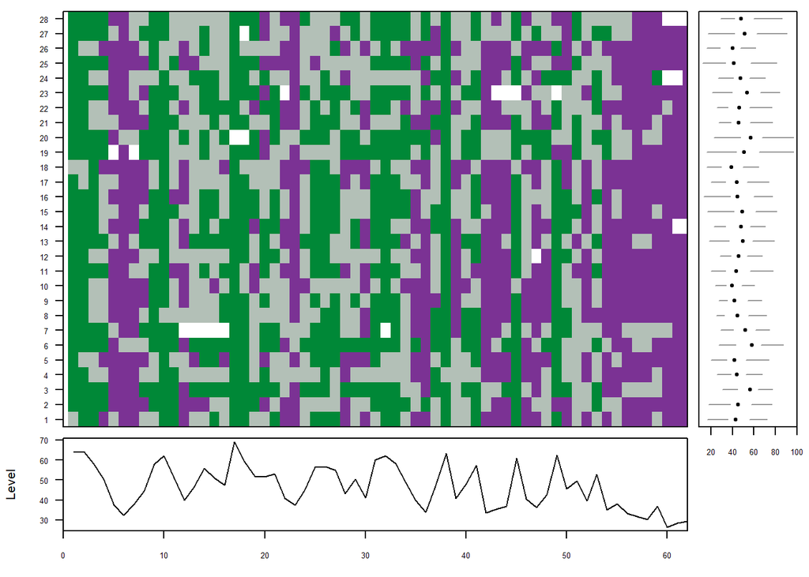

Daily ozone levels for 28 monitoring stations, Jul 1– Aug 31, 2006

```r
# Daily ozone levels for 28 monitoring stations, Jul 1– Aug 31, 2006.
mvtsplot(O3_wide, group = NULL, xtime = NULL, norm = c("global"),
         levels = 3, smooth.df = NULL, margin = TRUE, sort =NULL,
         main = "", palette = "PRGn", rowstat = "median", xlim,
         bottom.ylim = NULL, right.xlim=NULL, gcol = 3)
```

In the plot we use as color `PRGn` (default) from the `RColorBrewer` palettes. Here green indicates high values and purple indicates low values. Missing data are denoted by the color white. The bottom panel shows the overall median. Finally, on the right hand side panel, we can see the boxplots of the data in each time series.

- Moreover, we can check the basic statistics for ozone concentrations and make the histogram:

```r
summary(nysptime$y8hrmax)
```

```
##    Min. 1st Qu.  Median    Mean 3rd Qu.    Max.    NA's
##   12.38   37.35   46.50   47.82   57.63  107.00      24
```

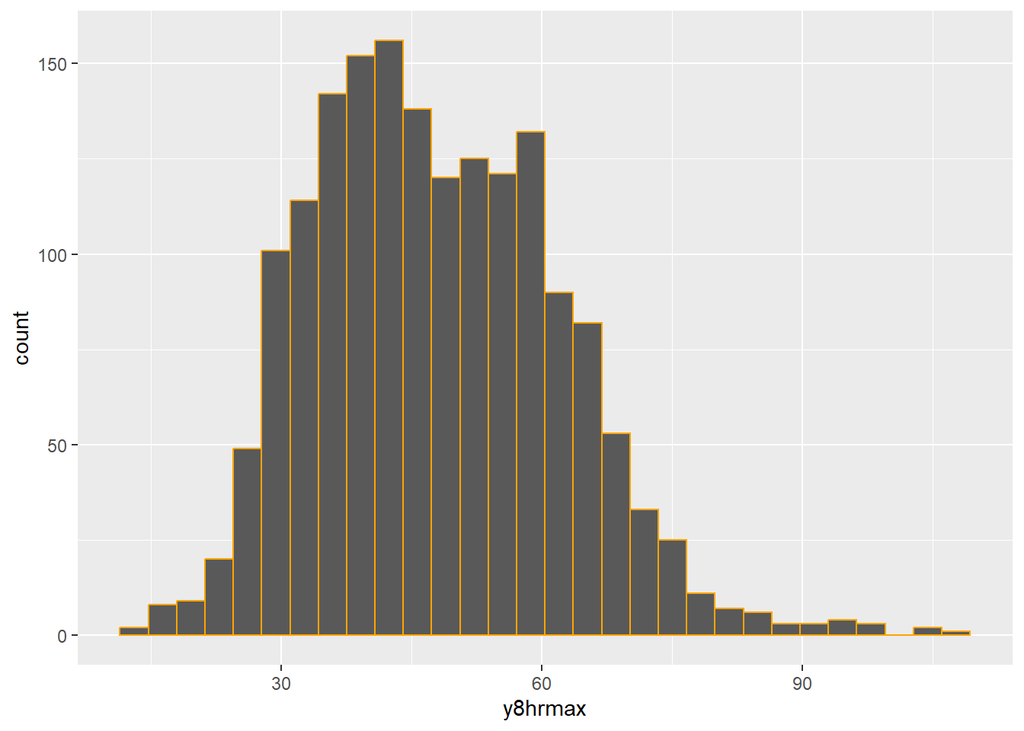

Histgram of ozone concentrations

```r
nysptime %>%
  ggplot()+
  geom_histogram(aes(y8hrmax), col="orange")
```

- We can visualize the relationships between the data using `ggpairs()` in the `GGally` package :

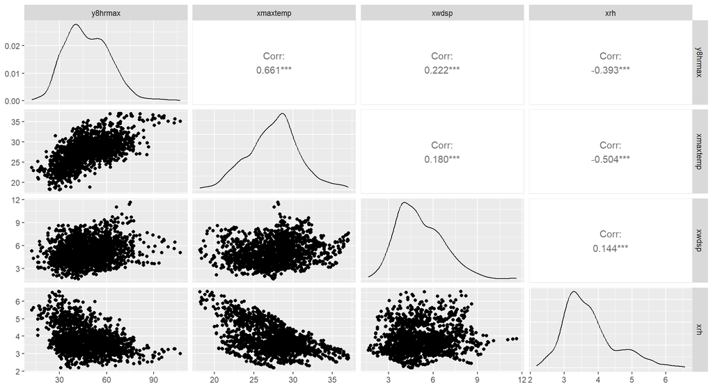

Figure 4. Plot of the correlation between variables in analysis

```r
library(GGally)
ggpairs(nysptime[,9:12]) # print correlations between variables
```

- We print the table of the correlations between ozone and the three predictors using the package `corrr`:

```r
library(corrr)
tab_cor = nysptime %>%
  select(y8hrmax, xmaxtemp, xwdsp, xrh) %>%
  correlate() %>%
  shave(upper = TRUE) %>%
  fashion(decimals = 2, na_print = "—")

tab_cor
```

```
##       term y8hrmax xmaxtemp xwdsp xrh
## 1  y8hrmax       —        —     —   —
## 2 xmaxtemp     .66        —     —   —
## 3    xwdsp     .22      .18     —   —
## 4      xrh    -.39     -.50   .14   —
```

- We create now a variable named `time` which is an index for time

```r
nysptime$time = rep(1:n_distinct(nysptime$date),
                   n_distinct(nysptime$s.index))
dim(nysptime) #1736 (28stations*62 days)  14
```

```
## [1] 1736   14
```

- We consider only the first 30 time points for reducing the computational costs

```r
nysptime = nysptime %>% filter(time <= 30)
dim(nysptime) #840 (28stations*30 days)  14
```

```
## [1] 840  14
```

- In order to approximately normally distributed data for the response variable, compute the square root transformation of `y8hrmax` and create a new variable named `sqrty8hrmax`, then plot the histogram of data as we did before

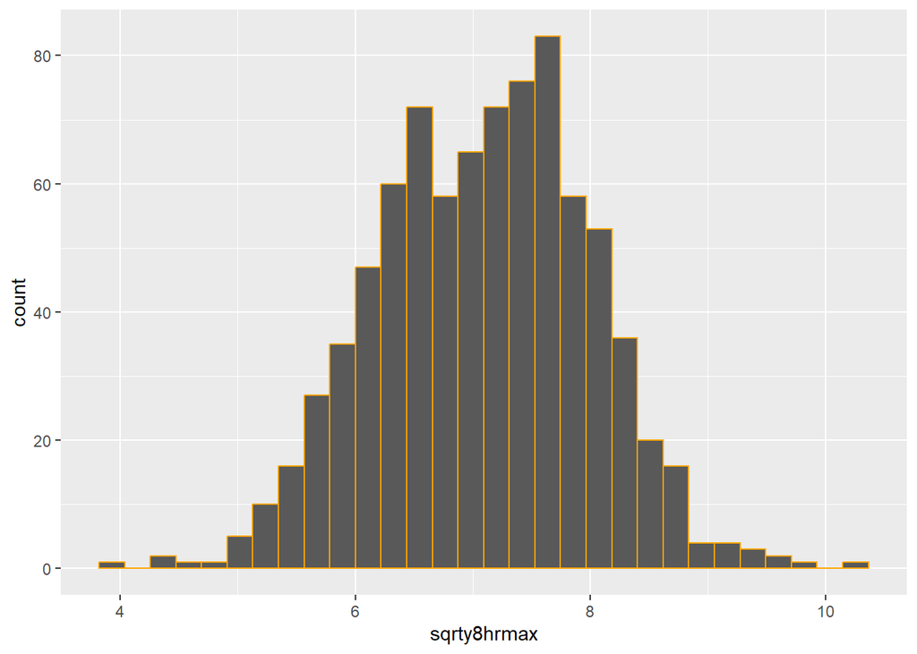

```r
nysptime$sqrty8hrmax = sqrt(nysptime$y8hrmax)

nysptime %>%
  ggplot()+
  geom_histogram(aes(sqrty8hrmax), col="orange")
```

- In this lab, we want also study the predictive capability of the model. To do so, we prepare two different datasets: the first, containing data for 8 stations, will be used for model validation, the second, with the data referring to the remaining stations, will be used for model training:

```r
# validation sites
s = c(8, 11, 12, 14, 18, 21, 24, 28) # 8 validation stations

# Training data
DataFit = nysptime %>%
  filter(!(s.index %in% s))
dim(DataFit)
```

```
## [1] 600  15
```

```r
# Dim = 600 (20stations*30days) * 15

# Validation data
DataValPred =  nysptime %>%
  filter(s.index %in% s)
dim(DataValPred)
```

```
## [1] 240  15
```

```r
# dim = 240 (8stations*30days) * 15
```

- We finally import and explore the grid that will be used for the predictions to obtain a continuous surface of ozone concentrations. To do so, we use the data in the `gridnysptime` object, which contains a total of 6200 rows for 62 days of observations for 10x10 = 100 grid points (see `?gridnysptime`).

```r
# ?gridnysptime
data(gridnysptime)
dim(gridnysptime)
```

```
## [1] 6200   11
```

```r
class(gridnysptime)
```

```
## [1] "data.frame"
```

```r
head(gridnysptime)
```

```
##   s.index Longitude Latitude     utmx    utmy Year Month Day xmaxtemp    xwdsp
## 1       1       -72     45.2 735621.3 5009547 2006     7   1 25.78623 5.602757
## 2       1       -72     45.2 735621.3 5009547 2006     7   2 29.35546 7.946272
## 3       1       -72     45.2 735621.3 5009547 2006     7   3 28.04157 3.891001
## 4       1       -72     45.2 735621.3 5009547 2006     7   4 26.55014 3.324329
## 5       1       -72     45.2 735621.3 5009547 2006     7   5 24.65790 5.221672
## 6       1       -72     45.2 735621.3 5009547 2006     7   6 23.54229 3.235730
##        xrh
## 1 3.311548
## 2 3.260382
## 3 2.804062
## 4 4.459596
## 5 4.096214
## 6 3.737357
```

## 3. Geostatistical spatio-temporal model

Now, we implement the spatio-temporal model for ozone concentrations:

- $\boldsymbol{Y}_t =(Y(\mathbf{s}_1,t), \dots, Y(\mathbf{s}_n,t))'$ be the observed data at location $\mathbf{s}$ in day $t$
- $\boldsymbol{O}_t =(O(\mathbf{s}_1,t), \dots, O(\mathbf{s}_n,t))'$ be the true value corresponding to $\boldsymbol{Y}_t$.

We use a hierarchical structure and we fit the following Bayesian model, with nugget effect model together with an independent Gaussian Process (GP) model at each time point:

$$\begin{equation*}
\begin{split}
\boldsymbol{Y}_t &= \boldsymbol{O}_t +\boldsymbol{\epsilon}_t\\
\boldsymbol{O}_t &= \boldsymbol{X}_t \boldsymbol{\beta} +
\boldsymbol{\eta}_t
\end{split}
\end{equation*}$$

where:

- $\boldsymbol{X}_t$ are the predictor values and $\boldsymbol{\beta}$ are the regression coefficients (i.e. large-scale component)
- $\boldsymbol{\eta}_t=(\eta(\mathbf{s}_1,t), \dots, \eta(\mathbf{s}_n,t))'$ are the spatio-temporal random effects, assumed to follow $N(\mathbf{0}, \Sigma_{\eta})$ independently in time, where $\Sigma_{\eta}=\sigma_{\eta}^{2} S_{\eta}$, here $\sigma_{\eta}^2$ is the site invariant spatial variance and $S_{\eta}$ is the spatial correlation matrix. We assume that the latent spatio-temporal process changes in time with first order autoregressive (AR(1)) model.
- $\boldsymbol{\epsilon}_t=(\epsilon(\mathbf{s}_1,t), \dots, \epsilon(\mathbf{s}_n,t))'$ is the nugget effect or the pure error term, independent in space and time.

The model we are going to implement is a separable model similar to the one described in Cameletti et al. (2013).

Remember that a spatio-temporal model is said to be separable when the space-time covariance structure can be decomposed into a spatial and a temporal term, i.e., the spatio-temporal covariance can be expressed as a Kronecker product of a spatial and a temporal covariance.

## 4. Prediction at the hold-out validation sites

### 4.1. Create the mesh and the SPDE model

- We start by creating a triangulation of our domain. First we establish the boundary of the domain with the function `inla.nonconvex.hull`, then we create the mesh with `inla.mesh.2d` function. A required parameter in the latter function is `max.edge`, which determines the largest allowed triangle length. If the value supplied to this argument is a scalar, it controls the triangle edge lengths in the inner domain; if a vector of two values is supplied, it controls the edge lengths in the inner domain and in the outer extension respectively. Notice that the value (or values) passed to the `max.edge` function must be on the same scale unit as the coordinates. For computational reason, we consider a slightly rough mesh. Here we work with the training data set, i.e. `DataFit`

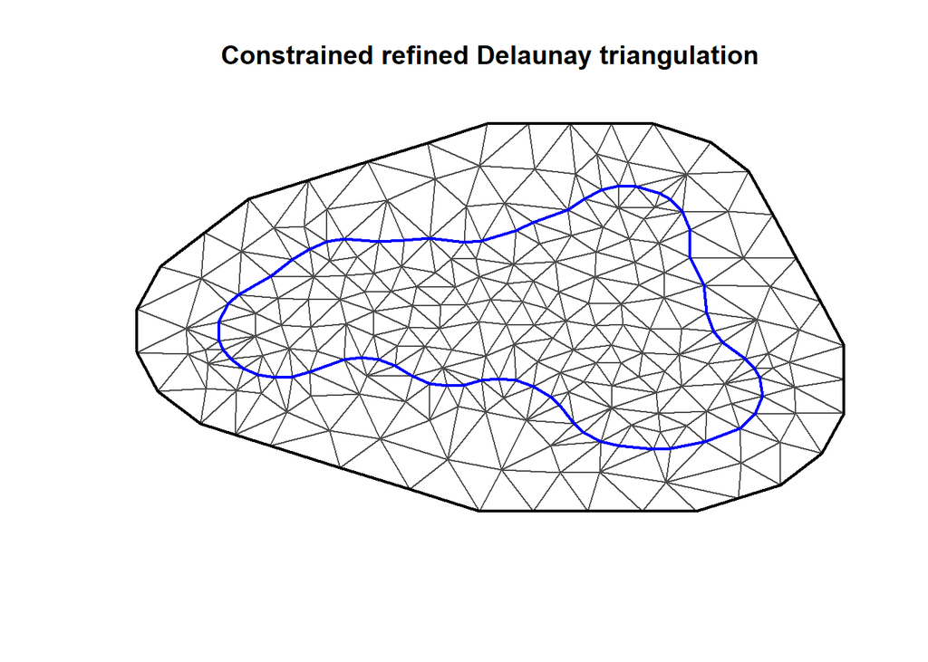

```r
coords.cv = unique(DataFit[c("Longitude", "Latitude")]) # coordinates for each station
boundary.cv = inla.nonconvex.hull(as.matrix(coords.cv[,1:2]))
mesh.cv = inla.mesh.2d(boundary = boundary.cv, max.edge = c(0.8, 1.3), cutoff = 0.1)
plot(mesh.cv)
```

- Now we plot the mesh with the station points included in the training dataset. To do so, we use the `gg()` function from the `inlabru` package

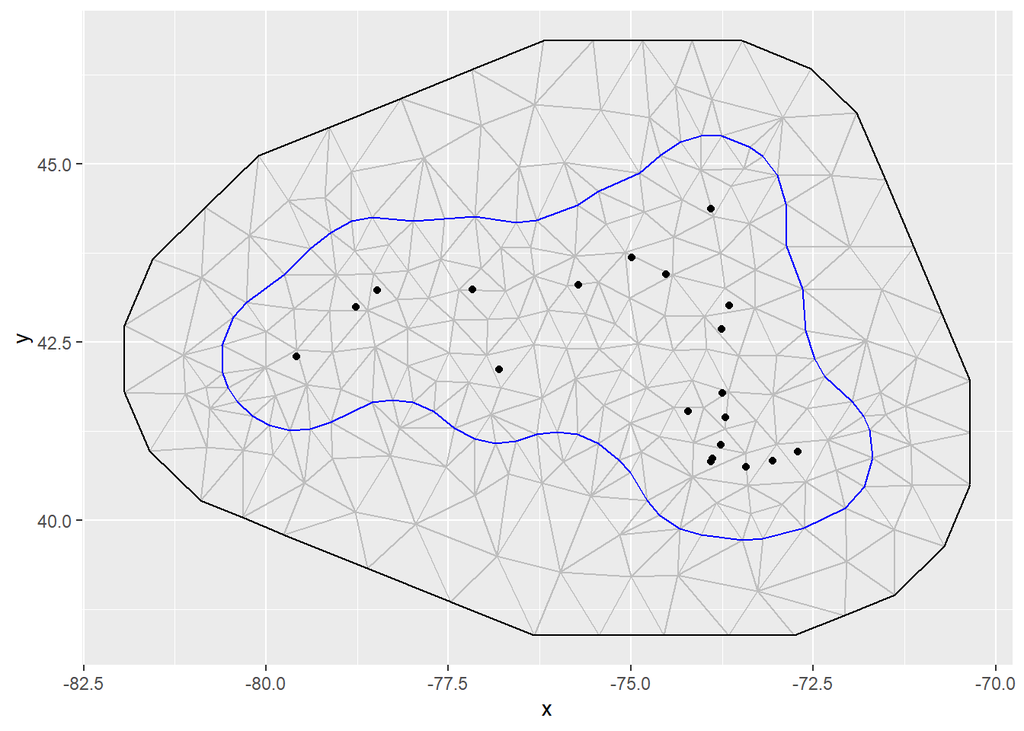

```r
ggplot() +
  gg(mesh.cv) +
  geom_point(data = coords.cv, aes(Longitude, Latitude))
```

- Given the mesh, it is now possible to create the SPDE model using the `inla.spde2.matern` function or `inla.spde2.pcmatern`. Here we use PC priors for the model. The range of the process is the distance such that the correlation between values is close to 0.1. In this study, we decide to use as a prior $p(range < 1) =0.01$. The parameter $\sigma$ denotes the variability of the data. We specify the prior for this parameter as $p(\sigma > 2) =0.01$. These PC priors are specified in the arguments `prior.range` and `prior.sigma` of the `inla.spde2.pcmatern()` function as follows:

```r
spde.cv = inla.spde2.pcmatern(mesh = mesh.cv, alpha = 2,
                           prior.range = c(1, 0.01),   # p(range < 1) = 0.01
                           prior.sigma = c(2, 0.01)) # p(sigma > 2) = 0.01

spde.cv$n.spde #n. of mesh vertices
```

```
## [1] 246
```

### 4.2 Create the index set and matrix A

- Create the index sets for the training data

```r
n_days = length(unique(DataFit$time))
n_spatial.cv = mesh.cv$n

s_index.cv = inla.spde.make.index(
  name = "spatial.field",
  n.spde = n_spatial.cv, # or n.spde = spde$n.spde
  n.group = n_days)
```

The s_index contains two important items: (i) the `spatial.field` index, which runs from 1 to `n_spatial` for `n_days` times, (ii) the `spatial.field.group`, which runs from 1 to `n_days`, with each element replicated `n_spatial` times.

- Create the project matrix using the function `inla.spde.make.A` function. This function takes as arguments the mesh, the measurement locations `loc`, the measurement group (here day), the number of groups:

```r
coordinates.alldays.cv = DataFit[c("Longitude", "Latitude")] %>% as.matrix()

Ae = inla.spde.make.A(mesh = mesh.cv,
                         loc = coordinates.alldays.cv,
                         group = DataFit$time,
                         n.group = n_days)
```

- Check the dimension of the projector matrix, and describe it

```r
dim(Ae)
```

```
## [1]  600 7380
```

Answer: The matrix A is equal in dimension to `number of observations` x `number of indices` of our basis functions in space and time. We can check this as follows:

```r
nrow(DataFit)
```

```
## [1] 600
```

```r
length(s_index.cv$spatial.field)
```

```
## [1] 7380
```

### 4.3. Define the stacks for the estimation and the predictions at the hold-out validation sites

- Define the stack for the estimation part

```r
stk_est = inla.stack(
  data = list(y = DataFit$sqrty8hrmax),
  A = list(Ae, 1),
  effects=list(c(s_index.cv,
        list(Intercept=1)),
        list(DataFit[,10:12])),
  tag="est")
```

- Define the stack for the prediction part
1. We now construct a stack for the prediction locations. To do so, we construct the matrix `Ap` from the prediction locations to the mesh nodes. We specify the prediction locations as `coords.val`

```r
coords.val = DataValPred[c("Longitude", "Latitude")]

groupp = DataValPred[, 14]

# Create A matrix for grid prediction
Ap = inla.spde.make.A(
  mesh =  mesh.cv,
  loc = as.matrix(coords.val),
 group = groupp,
  n.group = n_days)
dim(Ap)
```

```
## [1]  240 7380
```

2. Finally, we create the stack for the point predictions and the joint stack

```r
stk_pred = inla.stack(
  data = list(y = NA),
  A = list(Ap, 1),
  effects=list(c(s_index.cv, #Spatial field
          list(Intercept=1)),
          list(DataValPred[,10:12])),
          tag="pred")

# Final stack containing the estimation and prediction stacks
stk = inla.stack(stk_est, stk_pred)
```

### 4.4 Run INLA for the cross-validation excercise

- Now, we are ready to fit the model. We specify a PC prior on the AR(1) coefficient $\rho$, such that $p(\rho>0=0.9)$

```r
# prior for AR(1) coefficient
rho_hyper = list(theta = list(prior = "pccor1", param = c(0, 0.9)))
```

- We define the formula, including the intercept, 3 linear effects of the meteorological covariates and the spatio-temporal field (with AR(1) temporal dynamics):

```r
# formula
formula.cv = y ~ -1 + Intercept + xmaxtemp + xwdsp + xrh +
  f(spatial.field,
    model = spde.cv,
    group = spatial.field.group,
    control.group = list(model = "ar1",
                         hyper=rho_hyper))
```

- We fit the model

```r
# fit the model
fit.cv = inla(
  formula.cv,
  data = inla.stack.data(stk, spde = spde.cv),
  family = "gaussian",
  control.predictor = list(A = inla.stack.A(stk),
                           compute = TRUE),
  control.compute = list(return.marginals.predictor = TRUE))

summary(fit.cv)
```

```
##
## Call:
##    c("inla.core(formula = formula, family = family, contrasts = contrasts,
##    ", " data = data, quantiles = quantiles, E = E, offset = offset, ", "
##    scale = scale, weights = weights, Ntrials = Ntrials, strata = strata,
##    ", " lp.scale = lp.scale, link.covariates = link.covariates, verbose =
##    verbose, ", " lincomb = lincomb, selection = selection, control.compute
##    = control.compute, ", " control.predictor = control.predictor,
##    control.family = control.family, ", " control.inla = control.inla,
##    control.fixed = control.fixed, ", " control.mode = control.mode,
##    control.expert = control.expert, ", " control.hazard = control.hazard,
##    control.lincomb = control.lincomb, ", " control.update =
##    control.update, control.lp.scale = control.lp.scale, ", "
##    control.pardiso = control.pardiso, only.hyperparam = only.hyperparam,
##    ", " inla.call = inla.call, inla.arg = inla.arg, num.threads =
##    num.threads, ", " blas.num.threads = blas.num.threads, keep = keep,
##    working.directory = working.directory, ", " silent = silent, inla.mode
##    = inla.mode, safe = FALSE, debug = debug, ", " .parent.frame =
##    .parent.frame)")
## Time used:
##     Pre = 1.66, Running = 70.9, Post = 0.748, Total = 73.3
## Fixed effects:
##             mean    sd 0.025quant 0.5quant 0.975quant   mode kld
## Intercept  1.310 1.370     -1.387    1.311      3.999  1.315   0
## xmaxtemp   0.217 0.038      0.142    0.217      0.292  0.217   0
## xwdsp      0.036 0.034     -0.032    0.036      0.102  0.036   0
## xrh       -0.102 0.113     -0.323   -0.102      0.122 -0.103   0
##
## Random effects:
##   Name     Model
##     spatial.field SPDE2 model
##
## Model hyperparameters:
##                                           mean    sd 0.025quant 0.5quant
## Precision for the Gaussian observations 14.475 2.270     10.438   14.331
## Range for spatial.field                  2.736 0.385      2.073    2.703
## Stdev for spatial.field                  0.905 0.074      0.771    0.900
## GroupRho for spatial.field               0.736 0.050      0.629    0.739
##                                         0.975quant   mode
## Precision for the Gaussian observations     19.360 14.089
## Range for spatial.field                      3.586  2.629
## Stdev for spatial.field                      1.061  0.890
## GroupRho for spatial.field                   0.827  0.742
##
## Marginal log-Likelihood:  -480.08
##  is computed
## Posterior summaries for the linear predictor and the fitted values are computed
## (Posterior marginals needs also 'control.compute=list(return.marginals.predictor=TRUE)')
```

- We will explore the output and discuss the results in next sections 5-7, while here we complete the cross validation exercise by plotting together the observed (red) and predicted time series (posterior mean in black); the gray ribbon describes the posterior 95% interval to inspect the predictive capability of our model:

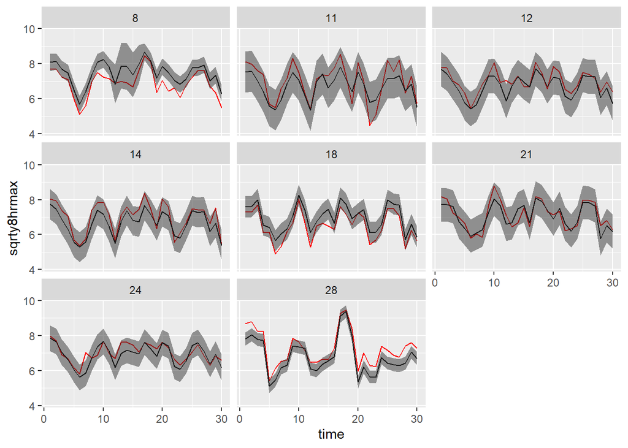

```r
index.pred.cv = inla.stack.index(stk, "pred")$data

## add to modmat the prediction and their sd
DataValPred$yPostMean = fit.cv$summary.fitted.values[index.pred.cv, "mean"]
DataValPred$ySD <- fit.cv$summary.fitted.values[index.pred.cv, "sd"]

## a plot with the original data
as.data.frame(DataValPred) %>%
  ggplot() +
  geom_line(aes(time, sqrty8hrmax, group = s.index), color = "red") +
  geom_line(aes(time, yPostMean, group = s.index)) +
  geom_ribbon(aes(time, ymin = (yPostMean - 2 * ySD), ymax = (yPostMean + 2 * ySD), group = s.index), alpha = 0.5) +
  facet_wrap(~ s.index)
```

## 5. Prediction on the grid

We now repeat all the same process to implement the model, but using the entire data set, i.e. `nysptime` and obtaining predictions on the entire domain.

### 5.1. Create the mesh and the SPDE model

- Now we create a triangulation of our domain. First we establish the boundary of the domain with the function `inla.nonconvex.hull`, then we create the mesh with `inla.mesh.2d` function, as we did before, but using all the data from the New York stations (i.e. `nysptime`)

```r
coords = unique(nysptime[c("Longitude", "Latitude")]) # coordinates for each station
boundary = inla.nonconvex.hull(as.matrix(coords[,1:2]))
mesh = inla.mesh.2d(boundary = boundary, max.edge = c(0.8, 1.3), cutoff = 0.1)
```

- Now we plot the mesh with the 28 station points. To do so, we use the `gg()` function from the `inlabru` package

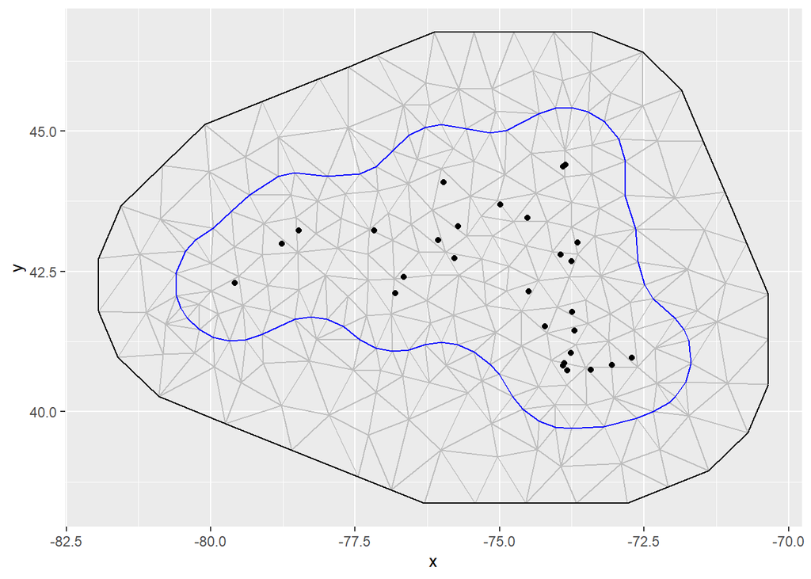

```r
ggplot() +
  gg(mesh) +
  geom_point(data = coords, aes(Longitude, Latitude))
```

- Given the mesh, it is now possible to create the SPDE model using the `inla.spde2.matern` function or `inla.spde2.pcmatern`. Here we use PC priors for the model. Create the SPDE model as we did before

```r
spde = inla.spde2.pcmatern(mesh = mesh, alpha = 2,
                           prior.range = c(1, 0.01),   # p(range < 1) = 0.01
                           prior.sigma = c(2, 0.01)) # p(sigma > 2) = 0.01

spde$n.spde #n. of mesh vertices
```

```
## [1] 255
```

### 5.2 Create the index set and matrix A

- Create the index sets

```r
n_days = length(unique(nysptime$time))
n_spatial = mesh$n

s_index = inla.spde.make.index(
  name = "spatial.field",
  n.spde = n_spatial, # or n.spde = spde$n.spde
  n.group = n_days)
```

The s_index contains two important items: (i) the `spatial.field` index, which runs from 1 to `n_spatial` for `n_days` times, (ii) the `spatial.field.group`, which runs from 1 to `n_days`, with each element replicated `n_spatial` times.

- Create the project matrix using the function `inla.spde.make.A` function. Remember from the previous section that this function takes as arguments the mesh, the measurement locations `loc`, the measurement group (here day), the number of groups

```r
coordinates.alldays = nysptime[c("Longitude", "Latitude")] %>% as.matrix()

A_est = inla.spde.make.A(mesh = mesh,
                         loc = coordinates.alldays,
                         group = nysptime$time,
                         n.group = n_days)
```

- Check the dimension of the projector matrix

```r
dim(A_est)
```

```
## [1]  840 7650
```

```r
nrow(nysptime)
```

```
## [1] 840
```

```r
length(s_index$spatial.field)
```

```
## [1] 7650
```

Answer: We see that the matrix A is equal in dimension to `number of observations` x `number of indices` of our basis functions in space and time.

### 5.3. Define the stacks for estimation and prediction

- Define the stack for the estimation part

```r
stack_est = inla.stack(
  data = list(y = nysptime$sqrty8hrmax),
  A = list(A_est, 1),
  effects=list(c(s_index,
        list(Intercept=1)),
        list(nysptime[,10:12])),
  tag="est")
```

- Define the stack for the prediction part
1. Firstly we displays the grid points together with the mesh:

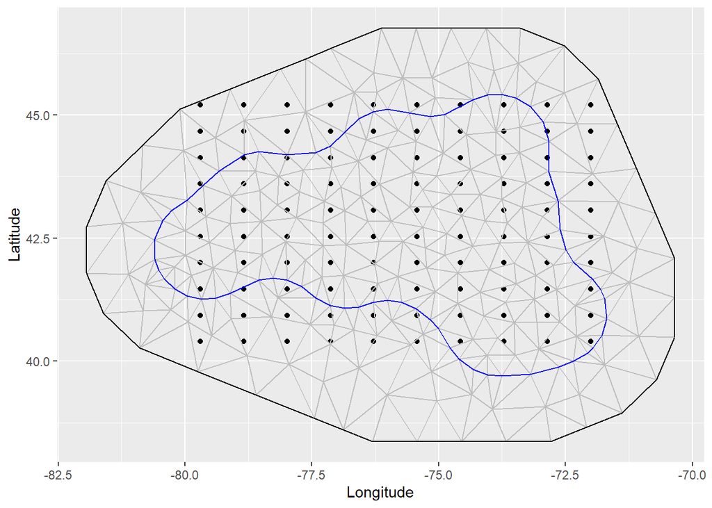

```r
gridnysptime %>%
  distinct(Longitude, Latitude) %>%
  ggplot()+
  geom_point(aes(Longitude, Latitude)) +
  gg(mesh)
```

2. Then, we create also for `gridnysptime` the variable containing the date information and then a variable which is an index for time:

```r
gridnysptime = gridnysptime %>%
  mutate(date = make_date(Year, Month, Day))

gridnysptime$time = rep(1:n_distinct(gridnysptime$date),
                   n_distinct(gridnysptime$s.index))

glimpse(gridnysptime)
```

```
## Rows: 6,200
## Columns: 13
## $ s.index   <int> 1, 1, 1, 1, 1, 1, 1, 1, 1, 1, 1, 1, 1, 1, 1, 1, 1, 1, 1, 1, …
## $ Longitude <dbl> -72, -72, -72, -72, -72, -72, -72, -72, -72, -72, -72, -72, …
## $ Latitude  <dbl> 45.2, 45.2, 45.2, 45.2, 45.2, 45.2, 45.2, 45.2, 45.2, 45.2, …
## $ utmx      <dbl> 735621.3, 735621.3, 735621.3, 735621.3, 735621.3, 735621.3, …
## $ utmy      <dbl> 5009547, 5009547, 5009547, 5009547, 5009547, 5009547, 500954…
## $ Year      <int> 2006, 2006, 2006, 2006, 2006, 2006, 2006, 2006, 2006, 2006, …
## $ Month     <int> 7, 7, 7, 7, 7, 7, 7, 7, 7, 7, 7, 7, 7, 7, 7, 7, 7, 7, 7, 7, …
## $ Day       <int> 1, 2, 3, 4, 5, 6, 7, 8, 9, 10, 11, 12, 13, 14, 15, 16, 17, 1…
## $ xmaxtemp  <dbl> 25.78623, 29.35546, 28.04157, 26.55014, 24.65790, 23.54229, …
## $ xwdsp     <dbl> 5.6027574, 7.9462719, 3.8910009, 3.3243287, 5.2216721, 3.235…
## $ xrh       <dbl> 3.311548, 3.260382, 2.804062, 4.459596, 4.096214, 3.737357, …
## $ date      <date> 2006-07-01, 2006-07-02, 2006-07-03, 2006-07-04, 2006-07-05,…
## $ time      <int> 1, 2, 3, 4, 5, 6, 7, 8, 9, 10, 11, 12, 13, 14, 15, 16, 17, 1…
```

3. For the sake of simplicity we consider only the first time point:

```r
gridnysptime = gridnysptime %>% filter(time == 1)
```

4. We construct a stack containing the matrices and vector defining the model at the prediction locations. To do so, we construct the matrix `A_pred` that projects the spatially continuous Gaussian random field from the prediction locations to the mesh nodes. We specify the prediction locations as `coords_grid`. We will make predictions at day 1:

```r
coords_grid = gridnysptime[c("Longitude", "Latitude")]

# define prediction day
i_day = 1
which_date = unique(nysptime$date)[i_day]
print(paste("* You will get a prediction for ", which_date, "*"))
```

```
## [1] "* You will get a prediction for  2006-07-01 *"
```

```r
#groupp = gridnysptime[, 13]

# Create A matrix for grid prediction
A_pred = inla.spde.make.A(
  mesh =  mesh,
  loc = as.matrix(coords_grid),
 #group = groupp,
 group = i_day,
  n.group = n_days)
dim(A_pred)
```

```
## [1]  100 7650
```

22. Finally, we create the stack for the predictions and the joint stack as we did before

```r
stack_pred = inla.stack(
  data = list(y = NA),
  A = list(A_pred, 1),
  effects=list(c(s_index, #Spatial field
          list(Intercept=1)),
          list(gridnysptime[,9:11])),
          tag="pred")

# Final stack containing the estimation and prediction stacks
stack = inla.stack(stack_est, stack_pred)
```

### 5.4 Run INLA

- Now, we are ready to fit complete the model. We specify a PC prior on the AR(1) coefficient $\rho$, such that $p(\rho>0=0.9)$ as we did for the cross-validation task

```r
# prior for AR(1) coefficient
rho_hyper = list(theta = list(prior = "pccor1", param = c(0, 0.9)))
```

- We define the formula, including the intercept, 3 linear effects of the meteorological covariates and the spatio-temporal field (with AR(1) temporal dynamics):

```r
# formula
formula = y ~ -1 + Intercept + xmaxtemp + xwdsp + xrh +
  f(spatial.field,
    model = spde,
    group = spatial.field.group,
    control.group = list(model = "ar1",
                         hyper=rho_hyper))
```

- We fit the model

```r
# fit the model
fit = inla(
  formula,
  data = inla.stack.data(stack, spde = spde),
  family = "gaussian",
  control.predictor = list(A = inla.stack.A(stack),
                           compute = TRUE),
  control.compute = list(return.marginals.predictor = TRUE))

summary(fit)
```

```
##
## Call:
##    c("inla.core(formula = formula, family = family, contrasts = contrasts,
##    ", " data = data, quantiles = quantiles, E = E, offset = offset, ", "
##    scale = scale, weights = weights, Ntrials = Ntrials, strata = strata,
##    ", " lp.scale = lp.scale, link.covariates = link.covariates, verbose =
##    verbose, ", " lincomb = lincomb, selection = selection, control.compute
##    = control.compute, ", " control.predictor = control.predictor,
##    control.family = control.family, ", " control.inla = control.inla,
##    control.fixed = control.fixed, ", " control.mode = control.mode,
##    control.expert = control.expert, ", " control.hazard = control.hazard,
##    control.lincomb = control.lincomb, ", " control.update =
##    control.update, control.lp.scale = control.lp.scale, ", "
##    control.pardiso = control.pardiso, only.hyperparam = only.hyperparam,
##    ", " inla.call = inla.call, inla.arg = inla.arg, num.threads =
##    num.threads, ", " blas.num.threads = blas.num.threads, keep = keep,
##    working.directory = working.directory, ", " silent = silent, inla.mode
##    = inla.mode, safe = FALSE, debug = debug, ", " .parent.frame =
##    .parent.frame)")
## Time used:
##     Pre = 1.64, Running = 75.2, Post = 0.404, Total = 77.3
## Fixed effects:
##             mean    sd 0.025quant 0.5quant 0.975quant   mode kld
## Intercept  0.992 1.318     -1.583    0.986      3.600  0.974   0
## xmaxtemp   0.224 0.036      0.151    0.224      0.295  0.224   0
## xwdsp      0.052 0.032     -0.011    0.052      0.115  0.053   0
## xrh       -0.077 0.107     -0.287   -0.077      0.133 -0.077   0
##
## Random effects:
##   Name     Model
##     spatial.field SPDE2 model
##
## Model hyperparameters:
##                                           mean    sd 0.025quant 0.5quant
## Precision for the Gaussian observations 12.794 1.233     10.557   12.727
## Range for spatial.field                  2.965 0.371      2.314    2.936
## Stdev for spatial.field                  0.982 0.112      0.792    0.971
## GroupRho for spatial.field               0.800 0.047      0.700    0.802
##                                         0.975quant   mode
## Precision for the Gaussian observations     15.409 12.584
## Range for spatial.field                      3.775  2.873
## Stdev for spatial.field                      1.232  0.943
## GroupRho for spatial.field                   0.884  0.806
##
## Marginal log-Likelihood:  -608.58
##  is computed
## Posterior summaries for the linear predictor and the fitted values are computed
## (Posterior marginals needs also 'control.compute=list(return.marginals.predictor=TRUE)')
```

## 6. Extract and analyse the posterior summaries

- We start by exploring the output names

```r
names(fit$marginals.fixed)
```

```
## [1] "Intercept" "xmaxtemp"  "xwdsp"     "xrh"
```

```r
names(fit$marginals.random)
```

```
## [1] "spatial.field"
```

```r
names(fit$marginals.hyperpar)
```

```
## [1] "Precision for the Gaussian observations"
## [2] "Range for spatial.field"
## [3] "Stdev for spatial.field"
## [4] "GroupRho for spatial.field"
```

- Extract the posterior summaries (mean and 95%CI credible intervals) for the fixed effects. Comment the results

```r
# Fixed effects
round(fit$summary.fixed[,c("mean","0.025quant","0.975quant")],3)
```

```
##             mean 0.025quant 0.975quant
## Intercept  0.992     -1.583      3.600
## xmaxtemp   0.224      0.151      0.295
## xwdsp      0.052     -0.011      0.115
## xrh       -0.077     -0.287      0.133
```

Comment: Using a subset of the New York data (only first 30 days are included), we see that the parameter estimates show that the max temperature has an impact on ozone concentrations, since the 95% credible intervals of the regression coefficients doesn’t contain zero.

- Now we plot the posterior densities for the fixed effects

```r
modfix = fit$summary.fixed
modfix
```

```
##                  mean         sd  0.025quant    0.5quant 0.975quant        mode
## Intercept  0.99161446 1.31833272 -1.58263370  0.98560052  3.6001670  0.97395481
## xmaxtemp   0.22359790 0.03646551  0.15140830  0.22378765  0.2947094  0.22415908
## xwdsp      0.05231426 0.03197461 -0.01092865  0.05247061  0.1146764  0.05278360
## xrh       -0.07707695 0.10695400 -0.28695974 -0.07717421  0.1333444 -0.07737822
##                    kld
## Intercept 4.556741e-09
## xmaxtemp  4.178188e-09
## xwdsp     3.240824e-09
## xrh       2.082143e-09
```

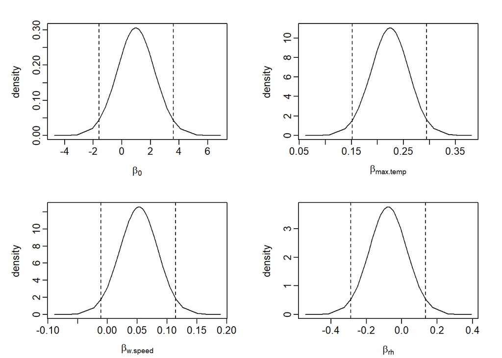

```r
par(mgp=c(2.2,0.45,0), tcl=-0.4, mar=c(3.3,4,2,2))
par(mfrow=c(2,2))

plot(fit$marginals.fix[[1]],type ='l',xlab=expression(beta[0]),ylab="density")
abline(v = modfix[1, c(3, 5)], lty=2)

plot(fit$marginals.fix[[2]],type ='l',xlab=expression(beta[max.temp]),ylab="density")
abline(v = modfix[2, c(3, 5)], lty=2)

plot(fit$marginals.fix[[3]],type ='l',xlab=expression(beta[w.speed]),ylab="density")
abline(v = modfix[3, c(3, 5)], lty=2)

plot(fit$marginals.fix[[4]],type ='l',xlab=expression(beta[rh]),ylab="density")
abline(v = modfix[4, c(3, 5)], lty=2)
```

- Now we check the posterior estimates of the hyperparameters. Obtain their posterior summaries, and call the object as `modhy`

```r
# Hyperparameters
modhy = fit$summary.hyperpar
modhy
```

```
##                                               mean         sd 0.025quant
## Precision for the Gaussian observations 12.7939284 1.23263246 10.5572054
## Range for spatial.field                  2.9645935 0.37122959  2.3144863
## Stdev for spatial.field                  0.9819929 0.11214864  0.7919374
## GroupRho for spatial.field               0.7998400 0.04713727  0.6998885
##                                           0.5quant 0.975quant       mode
## Precision for the Gaussian observations 12.7273735 15.4090637 12.5839589
## Range for spatial.field                  2.9362662  3.7747286  2.8727632
## Stdev for spatial.field                  0.9711795  1.2322277  0.9431347
## GroupRho for spatial.field               0.8024656  0.8837875  0.8057384
```

- We extract field, parameter values and distributions for the spatial field using the `inla.spde2.result` function (https://rdrr.io/github/INBO-BMK/INLA/man/inla.spde.result.html). Here, the `do.tranf = TRUE` makes sure that marginals are calculated in the same scale as the data

```r
output.field = inla.spde2.result(inla = fit,
                                  name = "spatial.field",
                                  spde = spde,
                                  do.transf = TRUE)
```

- Now we plot the posterior estimates for the parameter of the AR(1) model (coefficient $\rho$), the range that provides the distance value (in the unit of the point coordinates) above which spatial dependencies become negligible and the variance

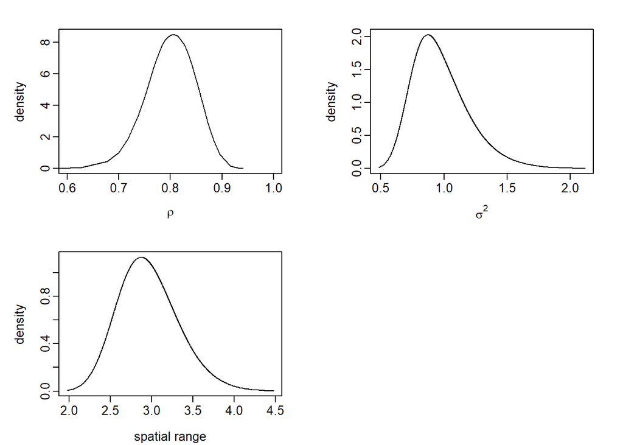

```r
out.range = exp(output.field$summary.log.range.nominal)
out.var = exp(output.field$summary.log.variance.nominal)

par(mgp=c(2.2,0.45,0), tcl=-0.4, mar=c(3.3,4,2,2))
par(mfrow=c(2,2))

# AR1 parameter
plot(fit$marginals.hyperpar$`GroupRho for spatial.field`,type = 'l',xlab = expression(rho),ylab = "density", xlim=c(0.6,1))

# range
plot(output.field$marginals.variance.nominal[[1]],type = 'l',xlab = expression(sigma^2),ylab = "density")

# variance
plot(output.field$marginals.range.nominal[[1]],type = 'l',xlab = "spatial range",ylab = "density")
```

- We check the correlation between the data response and the posterior mean of the predicted values

```r
# index for the random field at the data locations:
idat = inla.stack.index(stack_est, 'est')$data

# correlation between the data response and the posterior mean of the predicted values
cor(nysptime$sqrty8hrmax, fit$summary.linear.predictor$mean[idat], use="complete.obs")
```

```
## [1] 0.974855
```

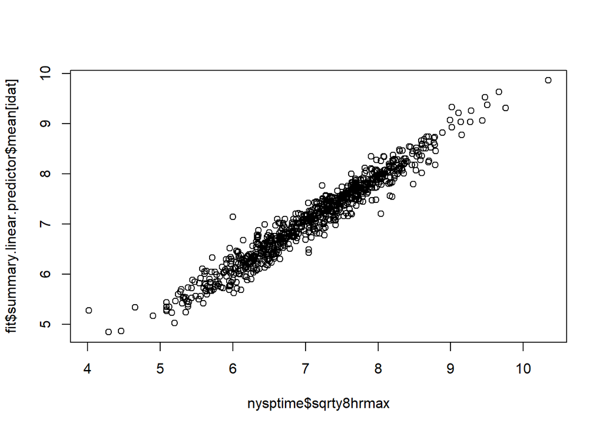

```r
# plot
plot(nysptime$sqrty8hrmax, fit$summary.linear.predictor$mean[idat])
```

## 7. Map of the predictions at grid level

- We extract the indices to the prediction nodes and then extract the posterior mean of the response at day 1. To do so, we use `inla.stack.index()` function to get the indices of stack that correspond to `tag = "pred"`

```r
# Get the posterior mean values
index.pred = inla.stack.index(stack, "pred")$data

post.mean.pred = fit$summary.linear.predictor[index.pred,"mean"]
post.sd.pred = fit$summary.linear.predictor[index.pred,"sd"]
#lp_marginals = fit$marginals.linear.predictor[index.pred]

# grid for the prediction
grid_locs = expand.grid(
  lon = seq(
  min(gridnysptime$Longitude),
  max(gridnysptime$Longitude),
  length.out = 10),
  lat = seq(
  min(gridnysptime$Latitude),
  max(gridnysptime$Latitude),
  length.out = 10))

# prepare posteriors for mapping
post.mean.df = SpatialPixelsDataFrame(SpatialPoints(grid_locs),
data = data.frame(post.mean.pred))

postsd.df = SpatialPixelsDataFrame(SpatialPoints(grid_locs),
data = data.frame(post.sd.pred))
```

- Finally we present the map of the smooth ozone concentration posterior mean (on the square root scale) and of the prediction standard error:

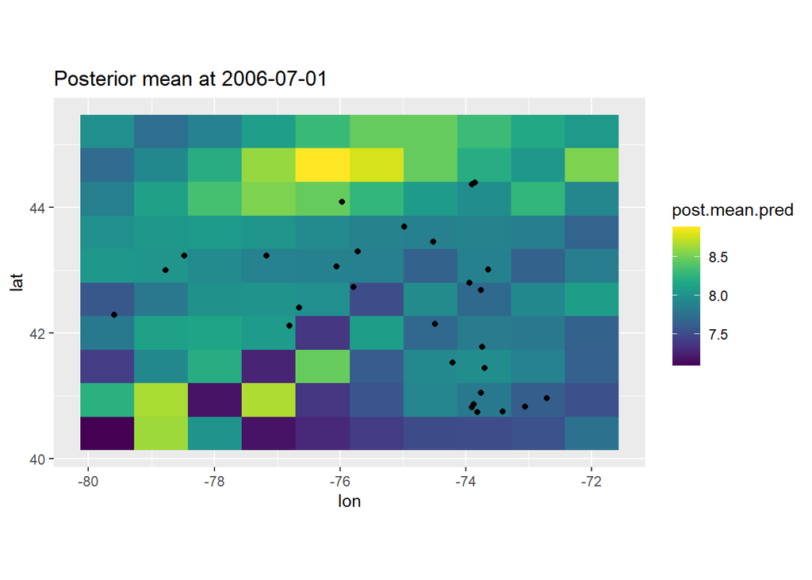

```r
# posterior mean
ggplot() +
  gg(post.mean.df, aes(lon, lat, fill = post.mean.pred))  +
  ggtitle("Posterior mean at 2006-07-01") +
  scale_fill_viridis() +
  coord_equal()+
  geom_point(data = coords, aes(Longitude, Latitude))
```

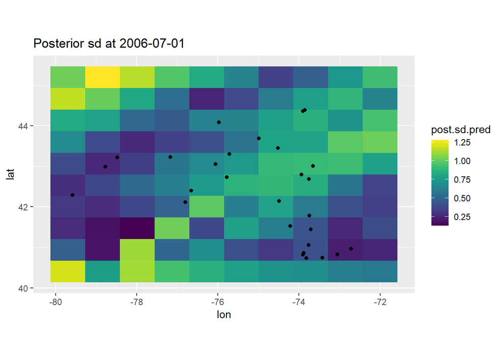

```r
# posterior standard deviation
ggplot() +
  gg(post.mean.df, aes(lon, lat, fill = post.sd.pred))  +
  ggtitle("Posterior sd at 2006-07-01") +
  scale_fill_viridis() +
  coord_equal()+
  geom_point(data = coords, aes(Longitude, Latitude))
```

Bakar, Khandoker Shuvo, and Sujit K. Sahu. 2015. “spTimer: Spatio-Temporal Bayesian Modeling Using R.” *Journal of Statistical Software* 63 (15): 1–32. http://www.jstatsoft.org/v63/i15.

Cameletti, Michela, Finn Lindgren, Daniel Simpson, and Håvard Rue. 2013. “Spatio-Temporal Modeling of Particulate Matter Concentration Through the SPDE Approach.” *AStA Advances in Statistical Analysis* 97: 109–31.

Sahu, Sujit K. 2022. *Bayesian Modeling of Spatio-Temporal Data with r*. Chapman; Hall/CRC.